# Nadaraya-Watson (2d) Kernel Regression

Jordan Schupbach

2025-11-03

## Introduction

This vignette demonstrates how to use the `mixedcurve` package to fit a Nadaraya-Watson kernel regression model to two-dimensional data.

## Example Usage

Let’s start by simulating some data according to the m2 Cuevas et al. function modified to two dimensions:

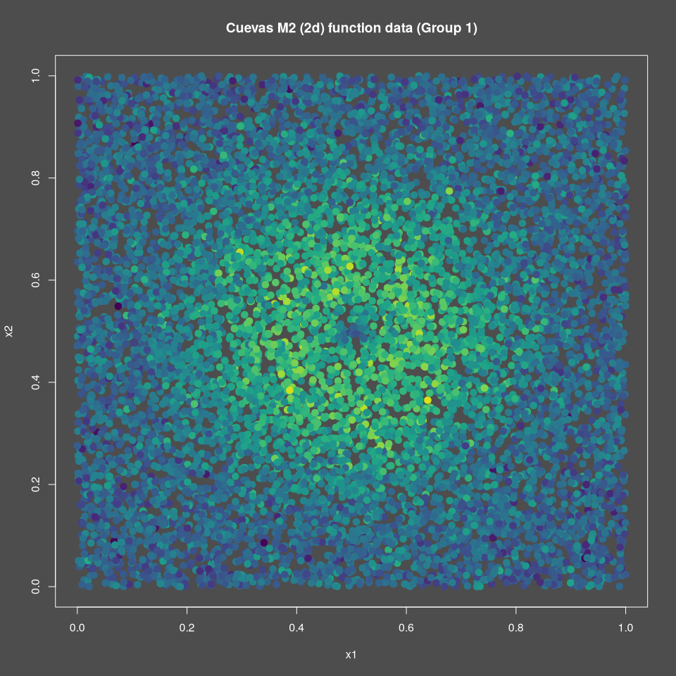

```r
library(mixedcurve)
nxy <- 5000
xseq <- seq(0, 1, length.out = 100)
set.seed(123)
df1 <- mixedcurve::gen_hfanova_data(
  f = mixedcurve::m2, n = c(nxy, 2), sigmas = c(0.02, 0),
  bounds = list(c(0,1), c(0, 1)), ndim = 2,
  ngrp = 1, px = NULL, pxargs = NULL,
  family = "gaussian", white_noise = TRUE
)
mixedcurve::dark_mode()
color_scale <- viridis::viridis(100)
color_values <- cut(df1$y, breaks = 100, labels = FALSE)
par(mfrow = c(1, 1))
plot(df1$x1, df1$x2,
     col = color_scale[color_values],
     pch = 20, xlab = "x1", ylab = "x2",
     main = "Cuevas M2 (2d) function data (Group 1)", cex = 2.0)
```

```r
#
```

To fit the Nadaraya-Watson kernel regression model, we can use the `lpk` function from the `mixedcurve` package. We will specify the bandwidth, kernel type, and degree and the function `y ~ K_h(x1 * x2)` to indicate a two-dimensional kernel regression on the 2d (product) space of `x1 * x2`.

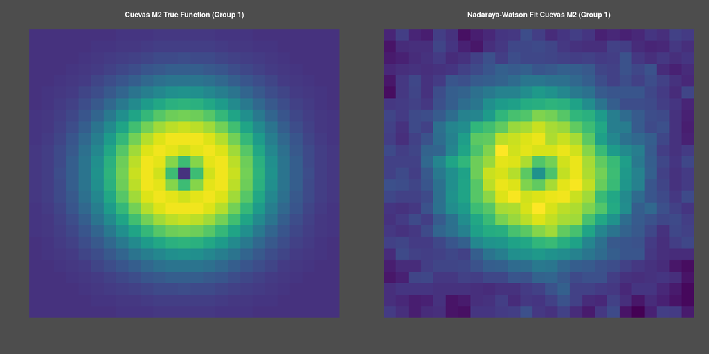

```r
# Fit Nadaraya-Watson kernel regression model (in parallel)
nq <- 25
qseq <- as.matrix(expand.grid(
  seq(0.0, 1.0, length.out = nq),
  seq(0.0, 1.0, length.out = nq))
)
bandwidth <- 0.015
cl <- parallel::makeCluster(parallel::detectCores() - 1)
invisible(parallel::clusterEvalQ(cl, library(mixedcurve)))
parallel::clusterExport(cl, varlist = c("df1", "bandwidth", "qseq"))
lpk2 <- mixedcurve::lpk(y ~ K_h(x1 * x2),
  alternative_hypothesis = y ~ K_h(x1 * x2 | -1),
  queries = qseq,
  data = df1, degree = 0, kernel = mixedcurve::gauss_kern,
  h = bandwidth, parallel = TRUE, cl = cl, kthresh = 0.1
)
parallel::stopCluster(cl)
fits <- as.numeric(unlist(lapply(lpk2[[1]], function (fit) fit$coefs)))
all_values <- c(fits, mixedcurve::m2(qseq, 1))
breaks <- seq(min(all_values), max(all_values), length.out = 101)
colors <- viridis::viridis(100)
mixedcurve::dark_mode()
par(mfrow = c(1, 2))
image(matrix(mixedcurve::m2(qseq, 1), nq, nq),
  col = colors, breaks = breaks,
  axes = FALSE, main = "Cuevas M2 True Function (Group 1)"
)
image(matrix(fits, nq, nq),
  col = colors, breaks = breaks,
  axes = FALSE, main = paste("Nadaraya-Watson Fit Cuevas M2 (Group 1)")
)
```

## WY Adjusted Test

We can also compute Westfall-Young adjusted p-values for the fitted model using

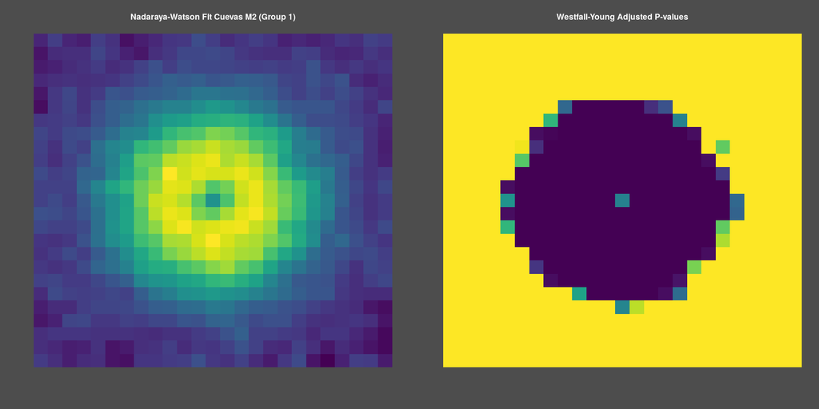

```r
cl <- parallel::makeCluster(parallel::detectCores() - 1)
invisible(parallel::clusterEvalQ(cl, library(mixedcurve)))
parallel::clusterExport(cl, varlist = c("df1", "bandwidth", "qseq"))
wy_pvals <- mixedcurve::wy_one_step(
  dataf = df1, xseq = qseq, nperm = 50,
  gen_pvals_fun = function(data, xseq) {
    lpk_res <- mixedcurve::lpk(
      y ~ K_h(x1 * x2), queries = xseq, data = data, degree = 0,
      kernel = mixedcurve::box_kern,
      h = bandwidth, parallel = FALSE,
      alternative_hypothesis = y ~ K_h(x1 * x2 | -1),
      kthresh = 0.1
    )
    as.numeric(do.call(cbind, lapply(lpk_res[[1]], function(elmt) {
      elmt$pvals
    })))
  },
  gen_perm_fun = function(data) {
    data$y <- sample(data$y, replace = FALSE)
    data
  },
  cl = cl
)
parallel::stopCluster(cl)
color_values <- cut(wy_pvals, breaks = 100, labels = FALSE)
colors <- viridis::viridis(100)
mixedcurve::dark_mode()
par(mfrow = c(1, 2))
image(matrix(fits, nq, nq),
  col = colors, breaks = breaks,
  axes = FALSE, main = paste("Nadaraya-Watson Fit Cuevas M2 (Group 1)")
)
image(matrix(wy_pvals, nrow = nq, ncol = nq),
  col = colors,
  axes = FALSE,
  main = "Westfall-Young Adjusted P-values"
)
```

We see that there is a large region in the central part of the domain where the Westfall-Young adjusted p-values are below the 0.05 significance threshold, corresponding to larger values of data, indicating that we can reject the null hypothesis that the mean function is equal to zero function. Further, we can see that the p-values are high for large region outside of that where the function is close to zero indicating regions where we do not have sufficient evidence to reject the null hypothesis.